# R Notebook

Libraries

```r
library(tibble)
library(ggplot2)
library(dplyr)
library(tidyr)
library(janitor)
library(purrr)
library(stringr)
library(visdat)
```

Dataset load

```r
salary_raw <- read.csv('Data/salary_data.csv')
fitness_members_raw <- read.csv('Project 3\\data\\fitness_members.csv', colClasses = c(id="character"))
fitness_tracking_raw <- read.csv('Project 3\\data\\fitness_tracking.csv', colClasses = c(id="character"))
fitness_members_missing_values <- read.csv('Data/fitness_members_missing_values.csv', colClasses = c(id="character"))%>%
  select(id, registration_date, gender, height, weight)
```

Quick presentation of the dataset:

```r
salary_raw
```

| salary | city |
| --- | --- |
| 35000 | Not in Capital |
| 40000 | Not in Capital |
| 70000 | Not in Capital |
| 44000 | Not in Capital |
| 45000 | Not in Capital |
| 73000 | Not in Capital |
| 50000 | Not in Capital |
| 27000 | Not in Capital |
| 34000 | Not in Capital |
| 37000 | Not in Capital |

[output cut: 490 more lines]

When describing our data, it most often makes sense to first visualize the data. I.e., we will have a look at how our data is distributed. We can then immediately get a general sense of what is going on in the data.

# Numerical data

Useful visualizations to examine the distribution of data are the boxplot and the histogram.

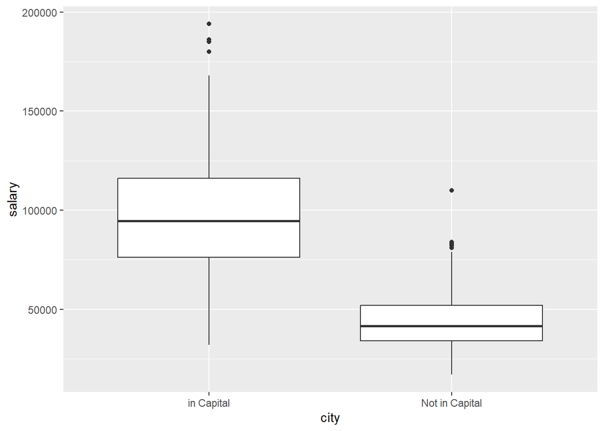

```r
ggplot(salary_raw, mapping = aes(x = city, y = salary)) +
  geom_boxplot()
```

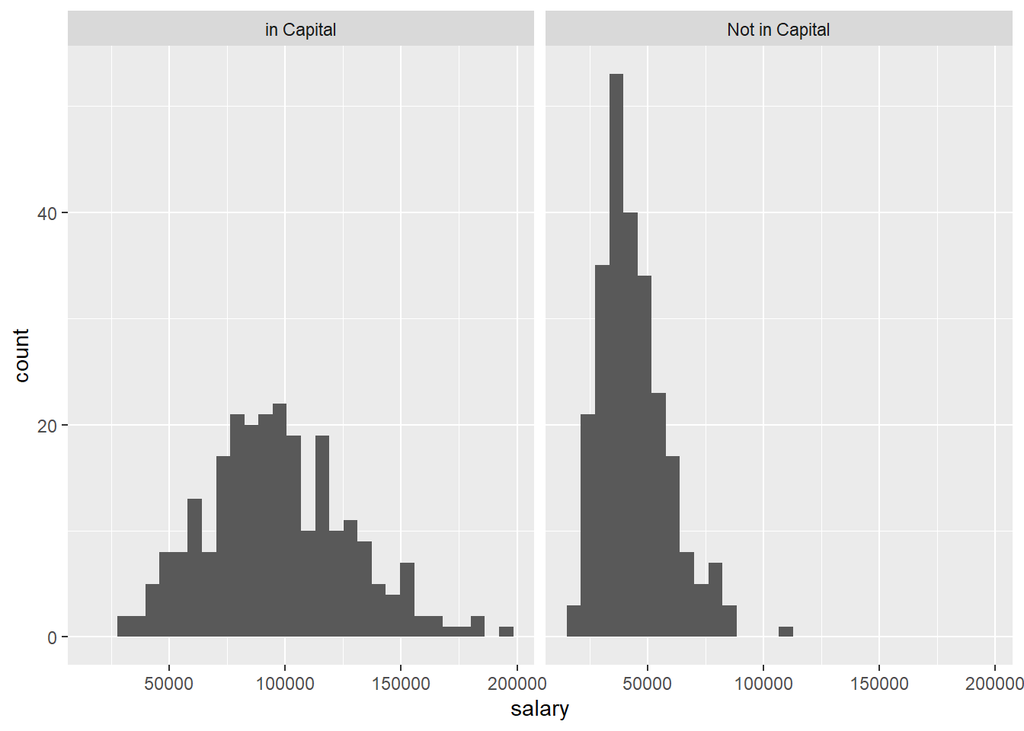

```r
ggplot(salary_raw, mapping = aes(x = salary)) +
  geom_histogram() +
  facet_wrap(~ city)
```

For now, we leave the visualization part for what it is. However, more techniques on visualizing descriptive statistics will be discussed in the next unit.

## Mean

```r
salary_raw %>%
  summarise(mean_salary = mean(salary))
```

| mean_salary |
| --- |
| 70592 |

Can you change the following code such that it calculates not the overall mean salary, but the mean split by living in the capital or not?

```r
salary_raw %>%
  group_by(city) %>%
  summarise(mean_salary = mean(salary))
```

| city | mean_salary |
| --- | --- |
| Not in Capital | 44252 |
| in Capital | 96932 |

## Median

While the mean has to do with the middle value, the median is more about the middle position. To obtain the median of a dataset we must first sort the values in numerical order from smallest to largest. If we have an odd number of values then the median is the unique value which lies in the middle position of our sorted list. If we have an even number of values then the median is the mean of the two values which lie in the middle positions.

```r
salary_raw %>%
  summarise(median_salary = median(salary))
```

| median_salary |
| --- |
| 61500 |

```r
salary_raw %>%
  group_by(city) %>%
  summarise(median_salary = median(salary))
```

| city | median_salary |
| --- | --- |
| Not in Capital | 41500 |
| in Capital | 94500 |

## The mode

The mode is perhaps the most intuitive measure to understand: it is simply the value which occurs the most often in a dataset. An easy way to remember the mode is using the acronym Most-often Occurring Data Element.

What if there is more than one value that appears the most often? In that case we consider each value that occurs the most often as the mode.

The mode is the trickiest value to obtain in R, as there is no function for it to do so. To obtain the mode, we would have to count() how often each value occurs, and then take the value, or values, that occur(s) the most.

```r
salary_raw %>%
  count(salary, sort = TRUE) %>%
  filter(n == max(n))
```

| salary | n |
| --- | --- |
| 36000 | 12 |
| 42000 | 12 |

```r
salary_raw %>%
  group_by(city) %>%
  count(salary, sort = TRUE) %>%
  filter(n == max(n))
```

| city | salary | n |
| --- | --- | --- |
| Not in Capital | 36000 | 12 |
| in Capital | 85000 | 7 |

Now you might wonder why we would want to have multiple ways of computing an average value. After all why can’t we just pick one and stick with it? As it turns out, they each have distinct properties that makes them appropriate for different scenarios. Let’s look again at our example.

Did you notice that the mean and the median salaries are very different from each other? Look at the following histogram, where the mean and median are highlighted :

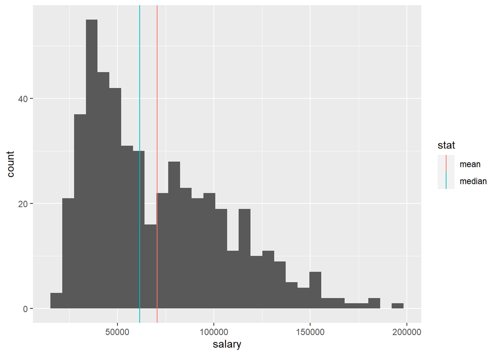

```r
ggplot(salary_raw, mapping = aes(x = salary)) +
  geom_histogram() +
  geom_vline(data = salary_raw %>%
               summarize(mean = mean(salary), median = median(salary)) %>%
               gather(stat, value, mean, median),
             mapping = aes(xintercept = value, colour = stat))
```

The mean lies much higher than the median. This is often the case when looking at salary data: because there are a few people that are earning much higher salaries than most people, the mean will be shifted to the right (it will be higher). You could argue that looking at the median in a case like this provides a better representation of the central tendency of the data than the mean.

# Categorical data

There are however two other ways in which we can describe ordinal and nominal data. The first one is frequency counts, which will reveal to us how many observations we have on each category.

Getting frequency tables in R is simple:

```r
salary_raw %>%
  count(city)
```

| city | n |
| --- | --- |
| Not in Capital | 250 |
| in Capital | 250 |

If this code looks familiar, this makes sense, because we used a very similar approach to calculate the mode for the salaries. Remember that the mode simply counts which value appears the most often in the data?

This means that we can use this statistic also for nominal and ordinal data. Simply put, the mode of a categorical column is the category that appears most often. Can you write code that reveals to us which category is the mode in this data?

# Descriptive statistics

## Spread

For this, the most straightforward measures to consider are the minimum, maximum, and range of the data. Knowing the minimum and maximum of the data is useful because it can help you determine whether all the values in your data are actually possible.

The range, further, is simply the distance between the minimum value of the data, and the maximum value of the data.

Can you calculate the minimum, maximum, and range of salary, and give the output in a tibble?

```r
salary_raw %>%
  summarise(min_salary = min(salary),
            max_salary = max(salary),
            range_salary = max_salary - min_salary)
```

| min_salary | max_salary | range_salary |
| --- | --- | --- |
| 17000 | 194000 | 177000 |

## Quartiles and interquartile range

In R, we can obtain the quartiles using the `quantile()` function. Have a look at the following code:

```r
salary_raw %>%
  summarise(q1 = quantile(salary, 0.25),
            q2 = quantile(salary, 0.5),
            q3 = quantile(salary, 0.75))
```

| q1 | q2 | q3 |
| --- | --- | --- |
| 40000 | 61500 | 95000 |

Before reading on, can you describe in your own words what the quantile() function does?

Say we want to split the data according to the first quartile. Recall that the first quartile splits the data at 25%, so that the lowest 25% of observations are split from the highest 75%. The quantile() function finds for the specified percentage point, in this case .25, the value in the data for which this happens. We find that in the salary data, a salary of 40’000 EXF lies on Q1.

There are two things to note.

- For statistical reasons, the split is expressed as a probability. So instead of saying 25, we type 0.25.
- Note that the function is called quantiles, not quartiles. This is because the function is not limited to the quartiles, but it can split the data by any value.

## The variance

As before, you don’t ever have to calculate variance and standard deviation by hand. Instead we can use R’s built-in functions:

```r
salary_raw %>%
  group_by(city) %>%
  summarise(variance_salary = var(salary),
            sd_salary = sd(salary))
```

| city | variance_salary | sd_salary |
| --- | --- | --- |
| Not in Capital | 217683229 | 14754.09 |
| in Capital | 960071663 | 30985.02 |

# Select the right graph!

## Graph for 1 variable

### Graph for 1 numerical continuous variable

Question : What is the distribution of member weights at week 0, when they register to the Fitness Club ?

Recommendation 1 : Do a Histogram

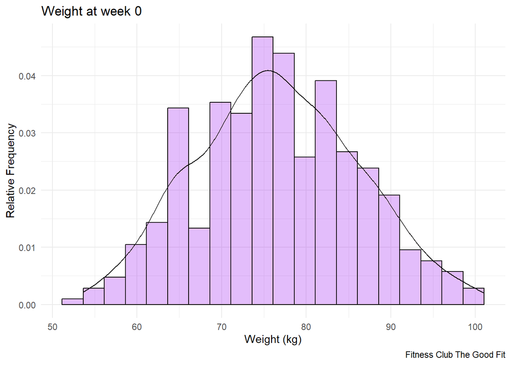

```r
fitness_members_raw %>% ggplot(aes(x = weight)) +
  geom_histogram(aes(y = after_stat(density)),
                 bins = 20,
                 colour = "black",
                 fill = "purple",
                 alpha = 0.3) +
  geom_density() +
  labs(title = "Weight at week 0",
       caption = "Fitness Club The Good Fit",
       x = "Weight (kg)",
       y = "Relative Frequency") +
  theme_minimal()
```

> Regarding the number of bins, it is recommended to take bins ≈√n, i.e. the square root of n, where n is the number of observations. We selected bins = 20 because it is the closest integer to √420

> ```
> Maths reminder: √9=3
> because 3×3=9
> ```

> R reminder: In R base, we can compute the square root of a number with the sqrt() function.

> When you make a histogram, we recommend that you add a density curve using the geom_density() function (see Plotting distributions in the Data Visualisation subject).

Recommendation 2 : Do a Boxplot

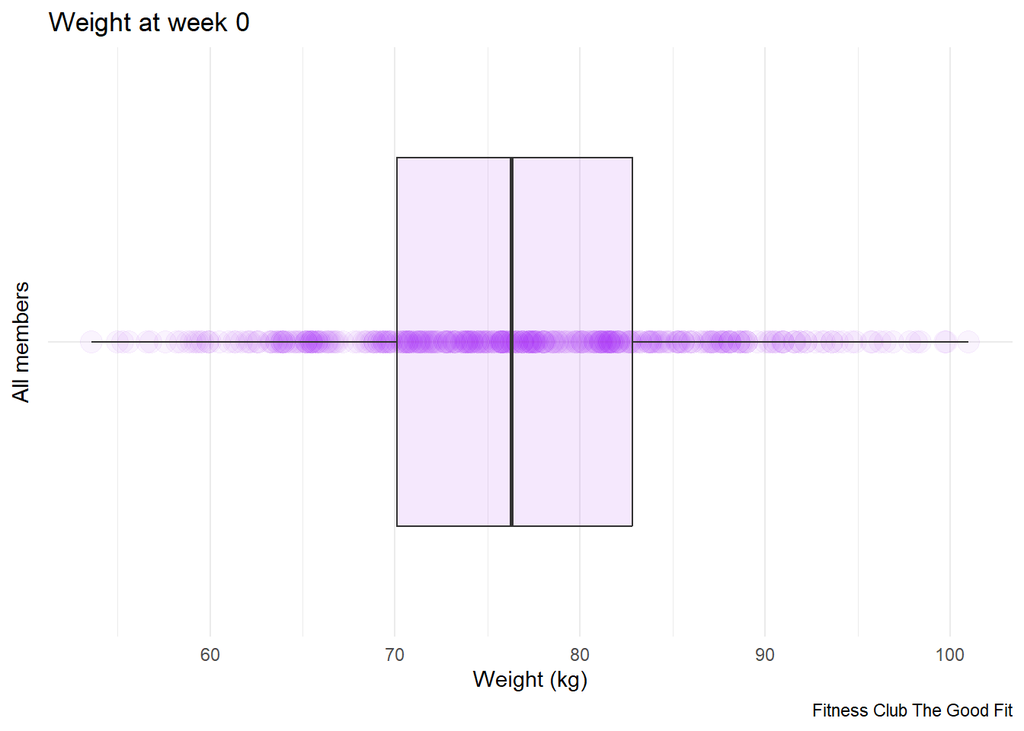

```r
fitness_members_raw %>% ggplot(aes(x = "", y = weight)) +
  geom_point(size = 5, alpha = 0.05, col = "purple") +
  geom_boxplot(alpha = 0.1, fill = "purple") +
  labs(title = "Weight at week 0",
       caption = "Fitness Club The Good Fit",
       x = "All members",
       y = "Weight (kg)") +
  coord_flip() +
  theme_minimal()
```

> When you produce a boxplot, we recommend that you plot as well the related data as shown in the figure above. This can be easily done using a geom_point() layer in addition to the geom_boxplot()layer (see corresponding code).

## One non-continuous variable (i.e. categorical or discrete)

Question : Is there a big difference between the number of members in the Premium category compared to the other categories Economic and Balance ?

Recommendation 1 : Do a Barplot

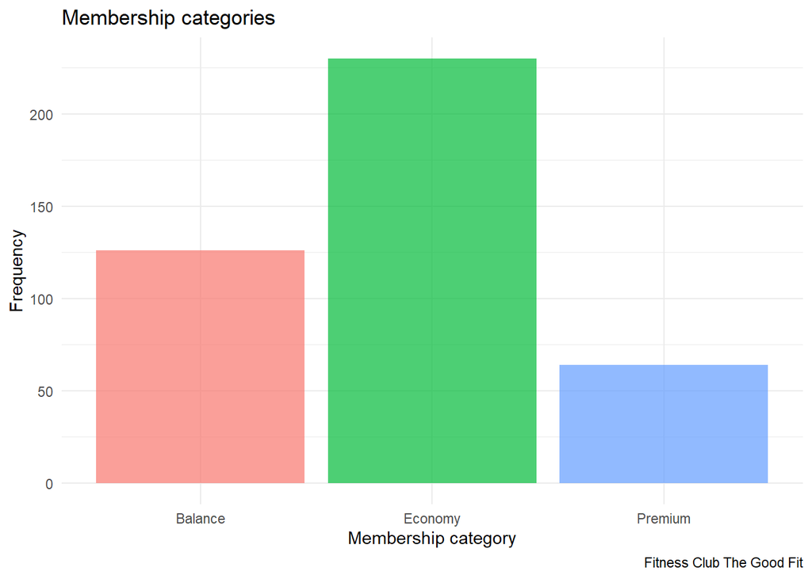

```r
mcategory_data <- fitness_members_raw %>%
  count(m_category, name = "frequency")

mcategory_data %>% ggplot(aes(x = m_category, y = frequency, fill = m_category)) +
  geom_col(alpha = 0.7) +
  labs(title = "Membership categories",
       caption = "Fitness Club The Good Fit",
       x = "Membership category",
       y = "Frequency") +
  theme_minimal() +
  theme(legend.position = "none")
```

Recommendation 2 : Do a Pie Chart

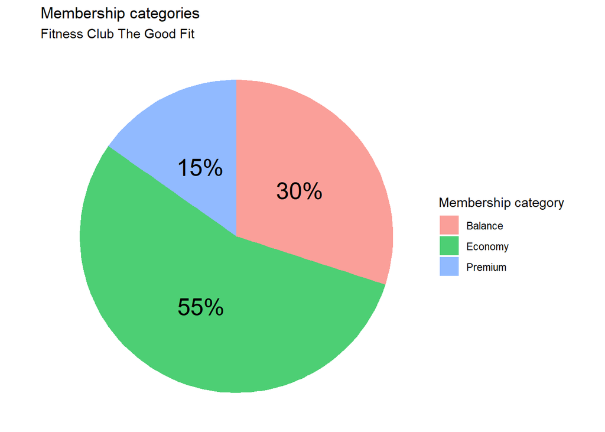

```r
mcategory_data <- fitness_members_raw %>%
  count(m_category, name = "frequency") %>%
  mutate(relative_frequency = round(100*frequency/sum(frequency)))

mcategory_data %>% ggplot(aes(x = "", y = frequency, fill = m_category)) +
  geom_col(alpha = 0.7) +
  coord_polar("y", start = 0, direction = -1) +
  geom_text(aes(label = paste0(relative_frequency, "%")),
            position = position_stack(vjust = 0.5),
            size = 7) +
  labs(title = "Membership categories",
       subtitle = "Fitness Club The Good Fit",
       fill = "Membership category") +
  theme_void()
```

Surprisingly, the pie chart is an extremely popular tool to visualise relative frequencies of category levels. Between a barplot and a pie chart, we prefer the first option because it is much easier to compare bar heights than angles of pie slices.

## Graph for 2 variables

### Continuous vs. Continuous

Question : Can we observe a strong relationship between weight and height ? Recommendation : Do a Scatterplot

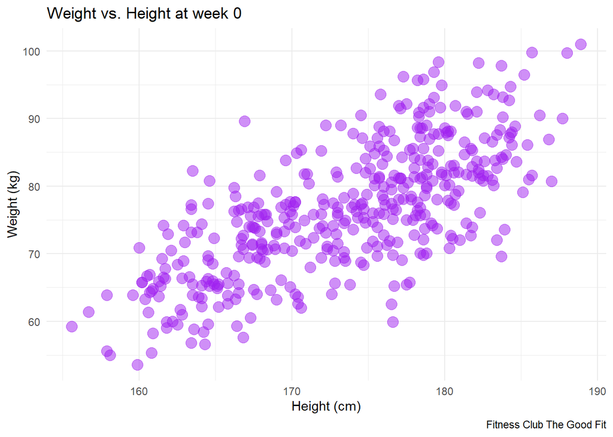

```r
fitness_members_raw %>% ggplot(aes(x = height, y = weight)) +
  geom_point(colour = "purple",
             size = 4,
             alpha = 0.5) +
  labs(title = "Weight vs. Height at week 0",
       caption = "Fitness Club The Good Fit",
       x = "Height (cm)",
       y = "Weight (kg)") +
  theme_minimal()
```

Question : Can we visualise for any specific member the evolution of weight through the first 12 weeks ? Recommendation : Do a Lineplot

```r
# Only get wk_000
week_one_tibble <- fitness_members_raw %>%
  mutate(wk_000 = weight) %>%
  select(id,height,wk_000)

colnames_fitness_tracker <- colnames(fitness_tracking_raw)
# Let's just remove the id column from this vector
colnames_fitness_tracker <- colnames_fitness_tracker[!colnames_fitness_tracker == 'id']
colnames_fitness_tracker <- append(colnames_fitness_tracker, 'wk_000')

# List of dfs to join them
list_df <- list(week_one_tibble, fitness_tracking_raw)

# Join both tibbles
fitness_tracking_with_wk_000 <- list_df %>%
  reduce(left_join, by='id')

# Now we can pivot longer
fitness_tracking_long <- fitness_tracking_with_wk_000 %>%
  pivot_longer(cols = all_of(colnames_fitness_tracker), names_to = "week_nb", values_to = "weight") %>%
  drop_na() %>%
  # We also need to create a new column with the week numbers as numeric, but we will also keep week_id
  rename(week_id = week_nb) %>%
  mutate(week_nb = as.numeric(str_remove(week_id, "wk_")))

fitness_tracking_long %>%
  head()
```

| id | height | week_id | weight | week_nb |
| --- | --- | --- | --- | --- |
| 000001 | 181.8 | wk_001 | 72.7 | 1 |
| 000001 | 181.8 | wk_002 | 71.8 | 2 |
| 000001 | 181.8 | wk_003 | 70.9 | 3 |
| 000001 | 181.8 | wk_004 | 70.7 | 4 |
| 000001 | 181.8 | wk_005 | 70.3 | 5 |
| 000001 | 181.8 | wk_006 | 70.4 | 6 |

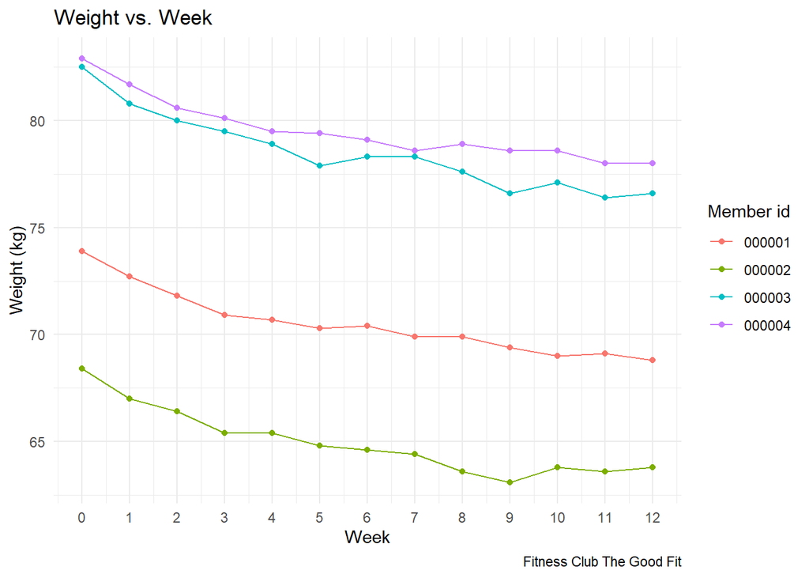

```r
fitness_tracking_long %>%
  filter(id %in% c("000001", "000002", "000003", "000004"),
         week_nb <= 12) %>%
  ggplot(aes(x = week_nb, y = weight, colour = id)) +
  geom_point() +
  geom_line() +
  labs(title = "Weight vs. Week",
       caption = "Fitness Club The Good Fit",
       x = "Week",
       y = "Weight (kg)",
       colour = "Member id") +
  scale_x_continuous(breaks = 0:12) +
  theme_minimal()
```

> Lineplots are particularly useful when the x-axis variable is time related. It is the case in our example where the x-axis variable is the number of weeks after registration to the Fitness Club.

Note that the above script uses the fitness_tracking_long tibble as input. This tibble was obtained from the fitness_tracking tibble which has a wide format (see unit What is data analysis). To show the evolution of the first 4 Fitness Club members over the first 12 weeks, we use the filter() function.

### Continuous vs. Non-continuous

Question : At week 0, corresponding to registration to the Fitness Club, how different is the distribution of weights for female fitness members compared to male fitness members ?

Recommendation 1 : Do a Histogram by Gender

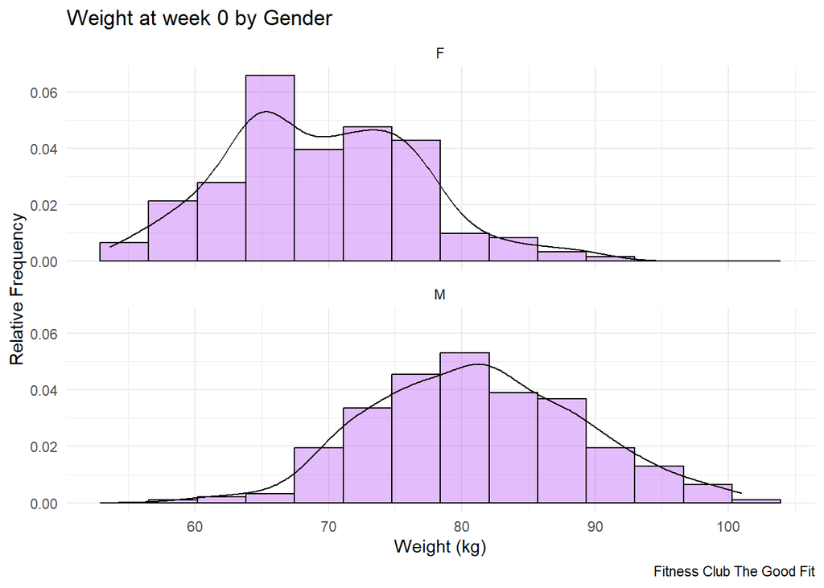

```r
fitness_members_raw %>% ggplot(aes(x = weight)) +
  geom_histogram(aes(y = ..density..),
                 bins = 14,
                 colour = "black",
                 fill = "purple",
                 alpha = .3) +
  geom_density() +
  labs(title = "Weight at week 0 by Gender",
       caption = "Fitness Club The Good Fit",
       x = "Weight (kg)",
       y = "Relative Frequency") +
  facet_wrap(vars(gender), ncol = 1) +
  theme_minimal()
```

Recommendation 2 : Do a Boxplot by Gender

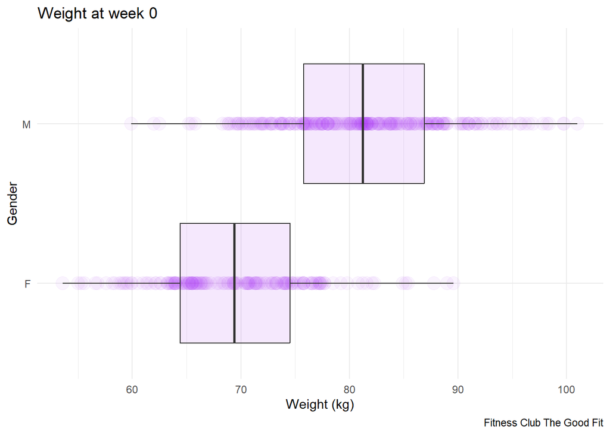

```r
fitness_members_raw %>% ggplot(aes(x = gender, y = weight)) +
  geom_point(size = 5, alpha = 0.05, col = "purple") +
  geom_boxplot(alpha = 0.1, fill = "purple") +
  labs(title = "Weight at week 0",
       caption = "Fitness Club The Good Fit",
       x = "Gender",
       y = "Weight (kg)") +
  coord_flip() +
  theme_minimal()
```

## Non-continuous vs. Non-continuous Question : When we compare the number of members in the Premium category to the other categories Economic and Balance, do we observe a similar pattern for female and male fitness members ?

Recommendation 1 : Do a Barplot by Gender

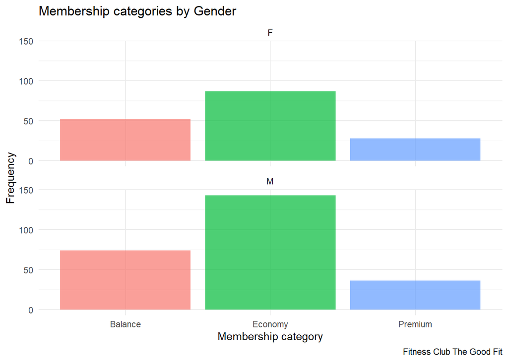

```r
mcategory_data <- fitness_members_raw %>%
  count(m_category, gender, name = "frequency")

mcategory_data %>% ggplot(aes(x = m_category, y = frequency, fill = m_category)) +
  geom_col(alpha = 0.7) +
  labs(title = "Membership categories by Gender",
       caption = "Fitness Club The Good Fit",
       x = "Membership category",
       y = "Frequency") +
  facet_wrap(vars(gender), ncol = 1) +
  theme_minimal() +
  theme(legend.position = "none")
```

Recommendation 2 : Do a Heatmap

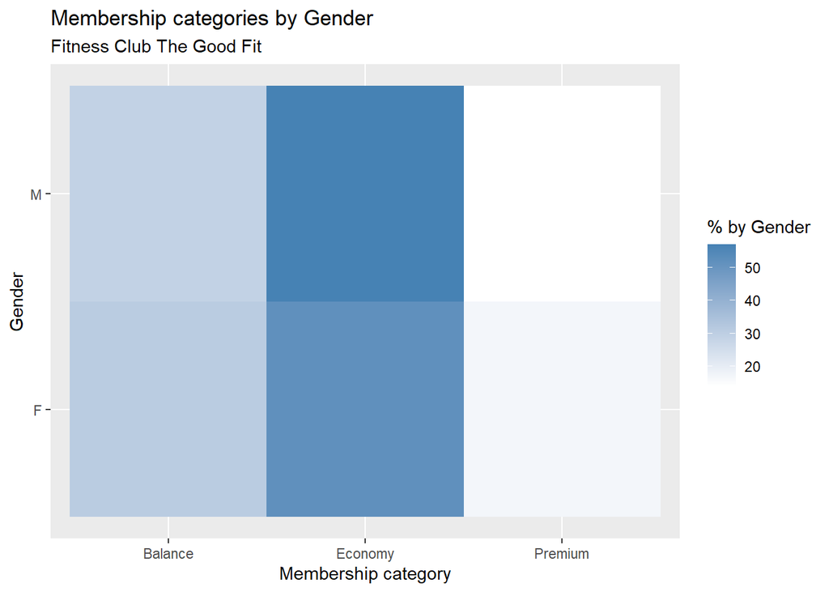

```r
mcategory_data <- fitness_members_raw %>%
  count(gender, m_category, name = "frequency") %>%
  group_by(gender) %>%
  mutate(relative_frequency = round(100*frequency/sum(frequency)))

mcategory_data %>% ggplot(aes(x = m_category, y = gender)) +
  geom_tile(aes(fill = relative_frequency)) +
  scale_fill_gradient(low = "white", high = "steelblue") +
  labs(title = "Membership categories by Gender",
       subtitle = "Fitness Club The Good Fit",
       x = "Membership category",
       y = "Gender",
       fill = "% by Gender")
```

Note that the input to produce the above heatmap is the mcategory_data tibble which is derived from the fitness_members tibble using the count() function. The heatmap is actually a visualisation of the resulting tibble detailed here below.

```r
mcategory_data
```

| gender | m_category | frequency | relative_frequency |
| --- | --- | --- | --- |
| F | Balance | 52 | 31 |
| F | Economy | 87 | 52 |
| F | Premium | 28 | 17 |
| M | Balance | 74 | 29 |
| M | Economy | 143 | 57 |
| M | Premium | 36 | 14 |

From the heatmap, you can already see that the distribution of membership categories is very similar for both male and female fitness members.

##What did your learn in this unit ?

[✓] To make sure that you have a specific question to answer before you plot the data !

[✓] To produce the recommended graphs when there is one variable to analyse, either Continuous or Non-continuous.

[✓] To produce the recommended graphs when there are two variables to analyse, for all possible combinations: Continuous vs. Continuous, Continuous vs. Non-continuous, and Non-continuous vs. Non-continuous.

# Dealing with missing values

One way to check whether a data set contains NA values is to use the {visdat} package that we learned about earlier in the course.

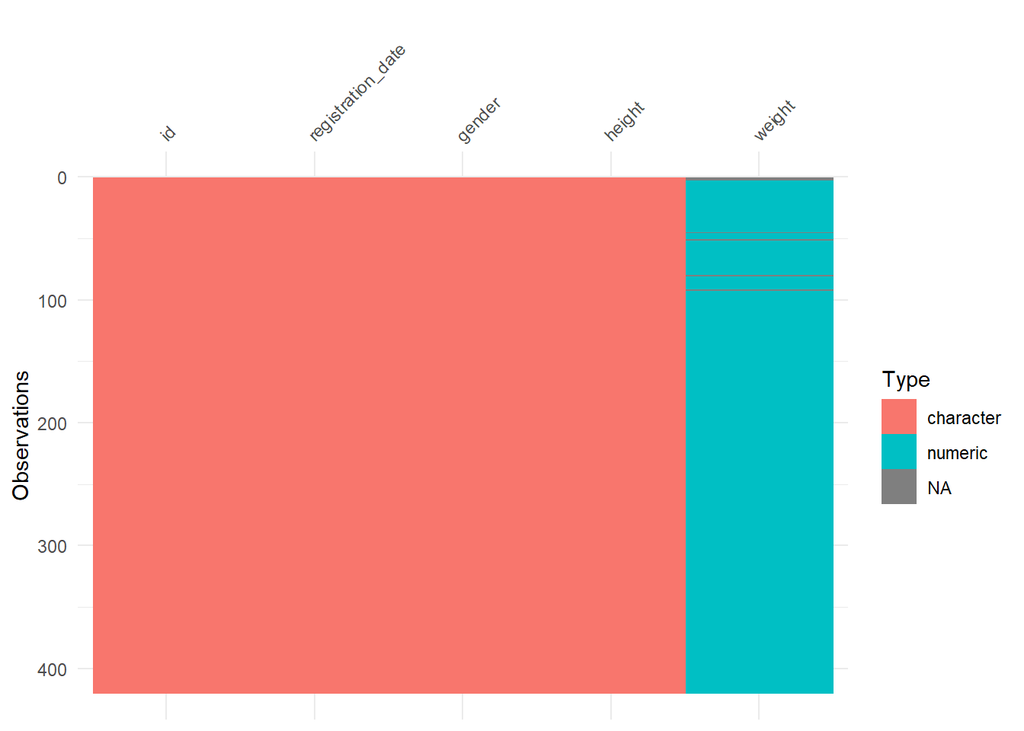

```r
vis_dat(fitness_members_missing_values)
```

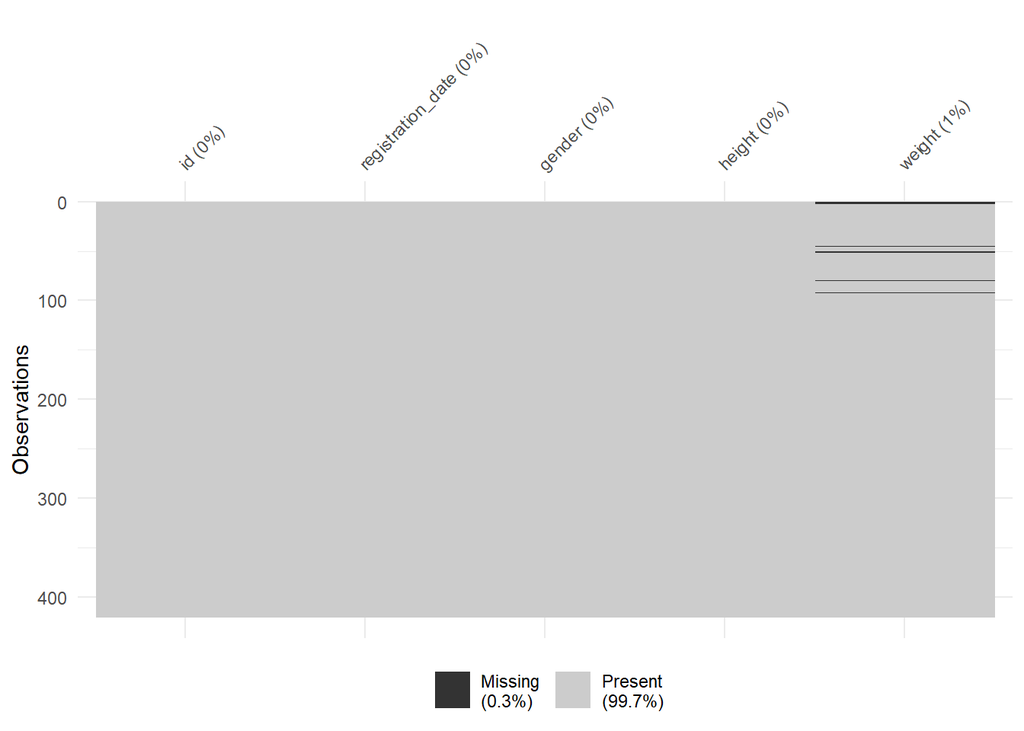

```r
visdat::vis_miss(fitness_members_missing_values)
```

We can also count the total number of NA values in the weight column using the simple technique below:

```r
fitness_members_missing_values %>%
  summarise(count = sum(is.na(weight)))
```

| count |
| --- |
| 6 |

From the result above, we can see that there are 6 NA values in the weight column. While we could simply omit these rows from the cleaned data set, doing so would mean that we’re omitting valueable data contained in all of the other columns next to the NA value. A better idea is to replace the NA with a relatively neutral statistic. We recommend using the median as a default, but if you think it makes sense for your data you may choose to use the average or even the mode. ## Imputing NA with the median Using the median will avoid the influence of outlier data on the substitute value. Outliers are another example of values that we might wish to replace in our data set, but for now let’s impute the NA values for weight with the median of all non NA values in the weight column.

The code below uses the replace() function, which takes three arguments. replace(x, list, values) will replace the values in a vector (x) at specific indices (list) with new values (values). In this way, we’re mutating weight below with a copy of itself where the missing values have been imputed.

```r
fitness_members_missing_values %>%
  mutate(weight = replace(weight, is.na(weight), median(weight, na.rm = TRUE)))
```

| id | registration_date | gender | height | weight |
| --- | --- | --- | --- | --- |
| 000001 | 2018-01-02 | F | 160.8 | 76.1 |
| 000002 | 2018-01-05 | M | 184.7 | 76.1 |
| 000003 | 2018-01-05 | M | 178.2 | 78.9 |
| 000004 | 2018-01-06 | M | 180.6 | 81.8 |
| 000005 | 2018-01-07 | M | 181.8 | 81.5 |
| 000006 | 2018-01-10 | F | 164.4 | 68.6 |
| 000007 | 2018-01-12 | F | 165.1 | 71.7 |
| 000008 | 2018-01-13 | M | 185.5 | 86.3 |
| 000009 | 2018-01-15 | M | 183.8 | 84.4 |
| 000010 | 2018-01-18 | M | 177.6 | 78.0 |

[output cut: 410 more lines]

You may be wondering which value is more representative of the missing data in a numeric column; the median or the mean. While to some extent this will vary depending on the distribution of the data in question, there’s another technique that we can use that will make our imputations even more reflective of the other values in the data set. All it takes is a little critical thinking, and a single line of code.

```r
weight_corrected <- fitness_members_missing_values %>%
  group_by(gender) %>%
  mutate(weight = replace(weight, is.na(weight), median(weight, na.rm = TRUE))) %>%
  ungroup()

weight_corrected
```

| id | registration_date | gender | height | weight |
| --- | --- | --- | --- | --- |
| 000001 | 2018-01-02 | F | 160.8 | 69.6 |
| 000002 | 2018-01-05 | M | 184.7 | 81.3 |
| 000003 | 2018-01-05 | M | 178.2 | 78.9 |
| 000004 | 2018-01-06 | M | 180.6 | 81.8 |
| 000005 | 2018-01-07 | M | 181.8 | 81.5 |
| 000006 | 2018-01-10 | F | 164.4 | 68.6 |
| 000007 | 2018-01-12 | F | 165.1 | 71.7 |
| 000008 | 2018-01-13 | M | 185.5 | 86.3 |
| 000009 | 2018-01-15 | M | 183.8 | 84.4 |
| 000010 | 2018-01-18 | M | 177.6 | 78.0 |

[output cut: 410 more lines]

In the example above, we grouped the data by gender before we calculated the median. Doing this makes the imputed values much more meaningful when we consider that, generally speaking, men weigh more than women. Now the median value is 69.6 for women, and 81.3 for men, rather than both being 76.1.

We can now also see that the number of NA values in the weight column has been reduced to zero:

```r
weight_corrected %>%
  summarise(count = sum(is.na(weight)))
```

| count |
| --- |
| 0 |

## Imputing non-standard NA values

You may have noticed by now that the height column doesn’t have the same class as the weight column. When we encounter situations like this, the right thing to do is to ask ourselves why that might be the case. Since letters will appear before numbers when we arrange a character column by ascending order, we can easily see whether the column contains any non-numeric values:

```r
weight_corrected %>%
  arrange(height)
```

| id | registration_date | gender | height | weight |
| --- | --- | --- | --- | --- |
| 000317 | 2019-03-09 | F | 155.6 | 63.9 |
| 000101 | 2018-05-21 | F | 156.7 | 62.0 |
| 000062 | 2018-03-17 | F | 158.1 | 71.4 |
| 000270 | 2018-12-29 | F | 159.6 | 62.4 |
| 000213 | 2018-10-06 | F | 159.9 | 68.6 |
| 000248 | 2018-11-29 | F | 160 | 61.3 |
| 000096 | 2018-05-18 | F | 160.2 | 69.2 |
| 000099 | 2018-05-19 | F | 160.2 | 66.7 |
| 000387 | 2019-07-08 | F | 160.4 | 72.6 |
| 000165 | 2018-08-12 | F | 160.5 | 58.1 |

[output cut: 410 more lines]

We can now see that height contains values for “N/A”, “na”, and “NA”. Each of these represents missing data, but before we can impute the median, we’ll need to convert the column to the dbl class, and these missing values to NA. The as.numeric() function will take care of that for us.

```r
weight_corrected <- weight_corrected %>%
  mutate(height = as.numeric(height))
weight_corrected %>%
  filter(is.na(height)) # Filter for just the NA height values
```

| id | registration_date | gender | height | weight |
| --- | --- | --- | --- | --- |
| 000418 | 2019-08-23 | M | NA | 90.7 |
| 000419 | 2019-08-25 | M | NA | 72.4 |
| 000420 | 2019-08-26 | F | NA | 64.7 |

Our data can now be used to calculate a relevant statistic that we can impute the missing height values with.

Imputing with the median is uncomplicated, but it is far from the most sophisticated statistic that we can use. One way to calculate a more meaningful substitute value would be to determine the relationship between two variables (correlation), and to use this correlation to calculate the missing value.

For example; we know that there is typically a strong correlation between weight and height for human beings. We can perform a regression analysis on our fitness_members data to determine this correlation from the data in the table. Below is a visualization of the correlation between height and weight for the fitness members.

We could use this correlation to predict the missing height values from their corresponding weight values. Generally speaking, this method will produce a more accurate substite value than the median. Visually, we could draw a vertical line from each of the known weight values, and the point on which the lines cross the regression line would correspond to the predicted height value.

Below we can see the points at which the dashed lines above correspond to the following predicted_height and actual_weight values:

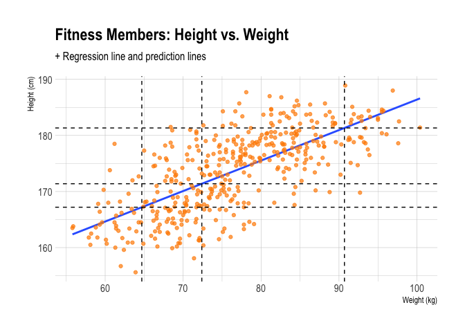

```
A tibble: 3 x 2
       actual_weight predicted_height
          <dbl>            <dbl>
1          90.7             181.
2          72.4             171.
3          64.7             167.
```

Using regression analysis is a concept that we’ll explore in greater detail very soon. In the meantime, just remember that there are different methods that we can use to predict missing values, and that regression analysis can be a good option for situations where there is a strong correlation between two variables.